# Assignment 3 workflow

2023-11-17

# Exploring the Socioeconomic Impacts of the 2021 Blackout in Houston, Texas

### Import Relevant Libraries

```r
library(terra)
library(dplyr)
library(spData)
library(spDataLarge)
library(tmap)
library(geodata)
library(stars)
library(sf)
library(tidyverse)
```

## Read in the Data

#### Nightlights Data:

```r
#Check the class of each object to ensure the data was read in as a stars object
class(tile5_Feb7)
```

```
## [1] "stars"
```

```r
class(tile5_Feb16)
```

```
## [1] "stars"
```

```r
class(tile6_Feb7)
```

```
## [1] "stars"
```

```r
class(tile6_Feb16)
```

```
## [1] "stars"
```

#### Highways Data:

We’ll be using queries to to access data from available databases. SQL is a Standardized Query Language that allows users on different operating systems and programming languages to access relational databases. The queries are the commands that access the data.

```r
#Use a query to import highways data
highway_query <- "SELECT * FROM gis_osm_roads_free_1 WHERE fclass='motorway'"
#Use st_read to read in the highway data as a spatial object
highways <- st_read("data/gis_osm_roads_free_1.gpkg", query = highway_query, quiet = TRUE)
```

#### Housing Data:

```r
#Use a query to import housing data
building_query <- "SELECT*
FROM gis_osm_buildings_a_free_1
WHERE (type IS NULL AND name IS NULL)
OR type in ('residential', 'apartments', 'house', 'static_caravan', 'detached')"
#Use st_read to read in the housing data as a spatial object
buildings <-  st_read("data/gis_osm_buildings_a_free_1.gpkg", query = building_query, quiet = TRUE)
```

#### Socioeconomic Data:

```r
#Use st_read to read in the geometry layer of the socioeconomic data
geometry <- st_read('data/ACS_2019_5YR_TRACT_48_TEXAS.gdb/', layer = "ACS_2019_5YR_TRACT_48_TEXAS")
#Use st_read to read in the socioeconomic data
socioeconomic <- st_read('data/ACS_2019_5YR_TRACT_48_TEXAS.gdb/', layer = 'X19_INCOME')
```

## Initial Data Exploration and Manipulation

#### Nightlights Data:

```r
#Combine tiles from the same day to create 2 comparable images
#Use st_mosaic to combine the two stars objects
Feb_7 = st_mosaic(tile5_Feb7, tile6_Feb7)
Feb_16 = st_mosaic(tile5_Feb16, tile6_Feb16)
```

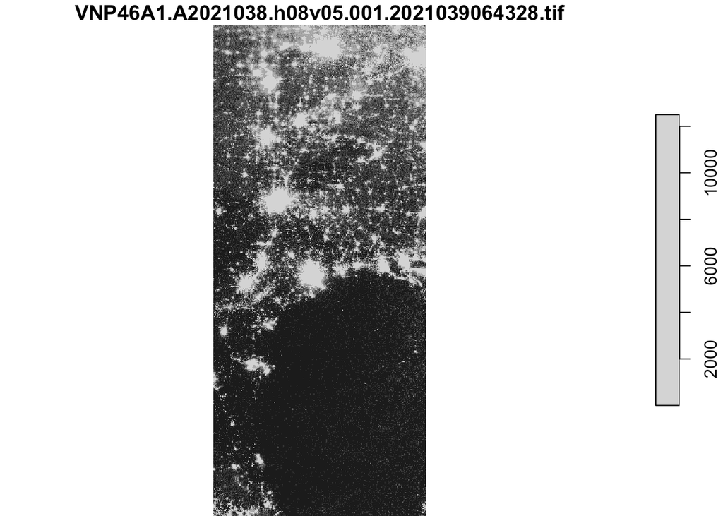

```r
#Check that the data was combined properly by plotting the image
plot(Feb_7)
```

```r
#Re-check the class of the new combined object
class(Feb_7)
```

```
## [1] "stars"
```

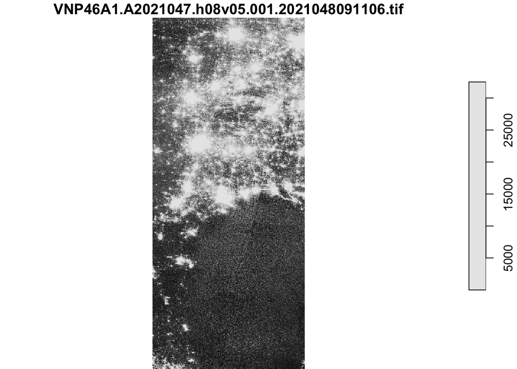

```r
#Check that the data was combined properly by plotting the image
plot(Feb_16)
```

```r
#Re-check the class of the new combined object
class(Feb_16)
```

```
## [1] "stars"
```

#### Highway Data:

```r
#Check the CRS of the highways data
crs(highways)
```

```
## [1] "GEOGCRS[\"WGS 84\",\n    ENSEMBLE[\"World Geodetic System 1984 ensemble\",\n        MEMBER[\"World Geodetic System 1984 (Transit)\"],\n        MEMBER[\"World Geodetic System 1984 (G730)\"],\n        MEMBER[\"World Geodetic System 1984 (G873)\"],\n        MEMBER[\"World Geodetic System 1984 (…
```

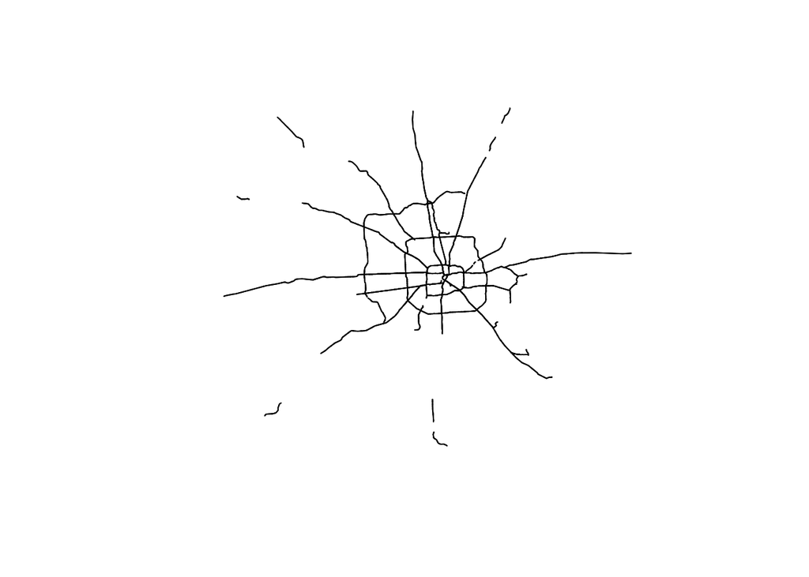

```r
#Transform the highways data to the EPSG 3083 projection
highways <- highways %>%
  st_transform(crs = 'EPSG:3083')
#Plot the initial data
plot(highways$geom)
```

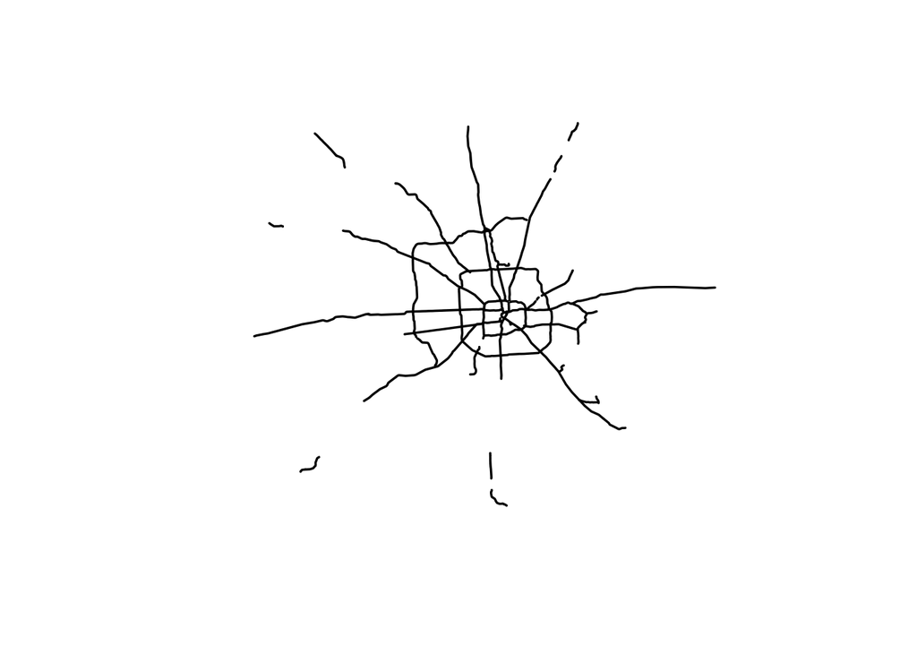

```r
#Add a 200m buffer around the highways so light coming from highways doesn't distort the data
buffer <- highways %>%
  st_buffer(dist = 200)
#Use st_union to join the highways data and the buffer into one cohesive geometry
highways_with_buffer <- buffer %>%
  st_union()
#Plot the highways data with the buffer to see the new data
plot(highways_with_buffer)
```

```r
#NOTE: toggling between the original highway data and the highway with buffer data allows you to see the line thickness change
#this ensures we actually made the buffer and added it to the geometry successfully
```

#### Socioeconomic Data:

```r
#Select only the GEOID and Median Income columns from the imported socioeconomic data
#Rename those columns for ease of use in the future
socioeconomic <- socioeconomic %>%
  dplyr::select(GEOID, B19013e1) %>%
  rename(GEOID_Data = GEOID,
    median_income = B19013e1)
```

```r
#Check the CRS of the original Geometry
crs(geometry)
```

```
## [1] "GEOGCRS[\"NAD83\",\n    DATUM[\"North American Datum 1983\",\n        ELLIPSOID[\"GRS 1980\",6378137,298.257222101,\n            LENGTHUNIT[\"metre\",1]]],\n    PRIMEM[\"Greenwich\",0,\n        ANGLEUNIT[\"degree\",0.0174532925199433]],\n    CS[ellipsoidal,2],\n        AXIS[\"geodetic latitu…
```

```r
#Join the geometery layer to the Census tract and Median Income data
#Reproject the data to the EPSG 3083 projection
census_income <- left_join(geometry, socioeconomic) %>%
  st_transform('EPSG:3083')

#Check that the data joined correctly by viewing the head of the data
head(census_income)
```

```
## Simple feature collection with 6 features and 16 fields
## Geometry type: MULTIPOLYGON
## Dimension:     XY
## Bounding box:  xmin: 1668040 ymin: 7257722 xmax: 1941468 ymax: 7624749
## Projected CRS: NAD83 / Texas Centric Albers Equal Area
##   STATEFP COUNTYFP TRACTCE       GEOID    NAME             NAMELSAD MTFCC
## 1      48      439  121609 48439121609 1216.09 Census Tract 1216.09 G5020
## 2      48      187  210708 48187210708 2107.08 Census Tract 2107.08 G5020
## 3      48      201  550301 48201550301 5503.01 Census Tract 5503.01 G5020
## 4      48      201  550302 48201550302 5503.02 Census Tract 5503.02 G5020
## 5      48      157  675800 48157675800    6758    Census Tract 6758 G5020
## 6      48      157  670800 48157670800    6708    Census Tract 6708 G5020
##   FUNCSTAT     ALAND  AWATER    INTPTLAT     INTPTLON Shape_Length   Shape_Area
## 1        S   4036421 2474977 +32.6893777 -097.2140987   0.14604256 0.0006260986
## 2        S   2625635       0 +29.5747421 -098.2516707   0.06645525 0.0002444645
## 3        S   2840437     680 +29.9841485 -095.4266424   0.08794497 0.0002655860
## 4        S   8876769   28534 +30.0052130 -095.4396816   0.12872622 0.0008326264
## 5        S 321634038 4618684 +29.5291745 -095.9737864   1.25764519 0.0303629632
## 6        S  14739824   72432 +29.5234624 -095.4691296   0.19854420 0.0013784329
##           GEOID_Data median_income                          Shape
## 1 14000US48439121609        120673 MULTIPOLYGON (((1758966 762...
## 2 14000US48187210708        104750 MULTIPOLYGON (((1668055 727...
## 3 14000US48201550301         30236 MULTIPOLYGON (((1939381 732...
## 4 14000US48201550302         47829 MULTIPOLYGON (((1936719 732...
## 5 14000US48157675800         47368 MULTIPOLYGON (((1878151 728...
## 6 14000US48157670800         74869 MULTIPOLYGON (((1933810 727...
```

## Task 1: Finding the locations of Blackouts

We’ll start by creating a blackout mask:

```r
#find the change in night lights intensity (presumably) caused by the storm
#assume that any location that experienced a drop of more than 200 nW cm-2sr-1 experienced a blackout
mask <- (Feb_7 - Feb_16) > 200

#assign NA to all locations that experienced a drop of less than 200 nW cm-2sr-1
mask[mask == FALSE] = NA
```

Then vectorize the mask:

```r
#use st_as_sf() to vectorize the blackout mask
blackout <- st_as_sf(mask)
#fix any invalid geometries using st_make_valid
blackout<- st_make_valid(blackout)
```

Finally, crop the vectorized map to our region of interest:

NOTE: We will assume the boundary of Houston can be defined by the following coordinates:

- (-96.5, 29), (-96.5, 30.5), (-94.5, 30.5), (-94.5, 29)

```r
#turn these coordinates into a polygon using st_polygon
Houston <- st_polygon(list(rbind(c(-96.5, 29),c(-96.5, 30.5),c(-94.5, 30.5), c(-94.5, 29),c(-96.5, 29))))
#convert the polygon into a simple feature collection using st_sfc() and assign a CRS
Houston <- st_sfc(Houston) %>%
  st_set_crs(4326)
```

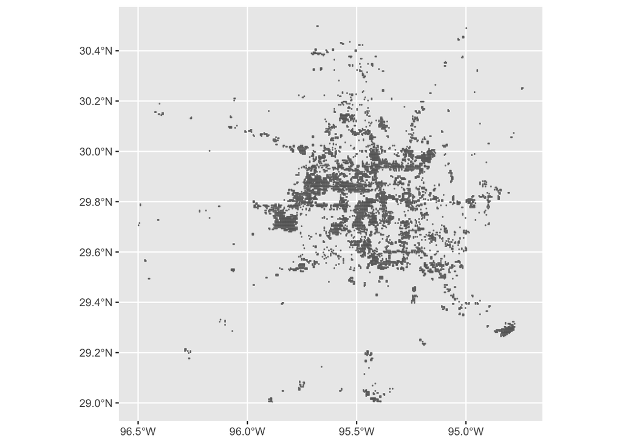

```r
#crop (spatially subset) the blackout mask to our region of interest
cropped_mask<- st_crop(blackout,Houston)
#Use the plot function to see that your data has been subsetted
ggplot()+
  geom_sf(data = cropped_mask$geometry)
```

```r
#re-project the cropped blackout dataset to EPSG:3083 (NAD83 / Texas Centric Albers Equal Area)
cropped_mask <- cropped_mask %>%
  st_transform('EPSG:3083') %>%
  st_make_valid()
```

To avoid mistaking differences in traffic for a blackout, remove the highways from the mask:

```r
#Use st_difference to select the areas that are within the cropped mask and outside the buffer
cropped_mask_no_highways <- st_difference(cropped_mask,highways_with_buffer)
#check to see that the subset worked by comparing the number of observations in each dataset:
print(nrow(cropped_mask))
```

```
## [1] 7256
```

```r
print(nrow(cropped_mask_no_highways))
```

```
## [1] 7247
```

Note: there are 7256 observations in our original dataset, and there are only 7247 observations in the new dataset.

## Find homes impacted by blackouts

```r
#Reproject the buildings data to be the same CRS
buildings <- buildings %>%
  st_transform('EPSG:3083')
#Use st_within to select buildings that are within our blackout mask
homes_with_blackouts <- st_intersection(buildings,cropped_mask_no_highways)
```

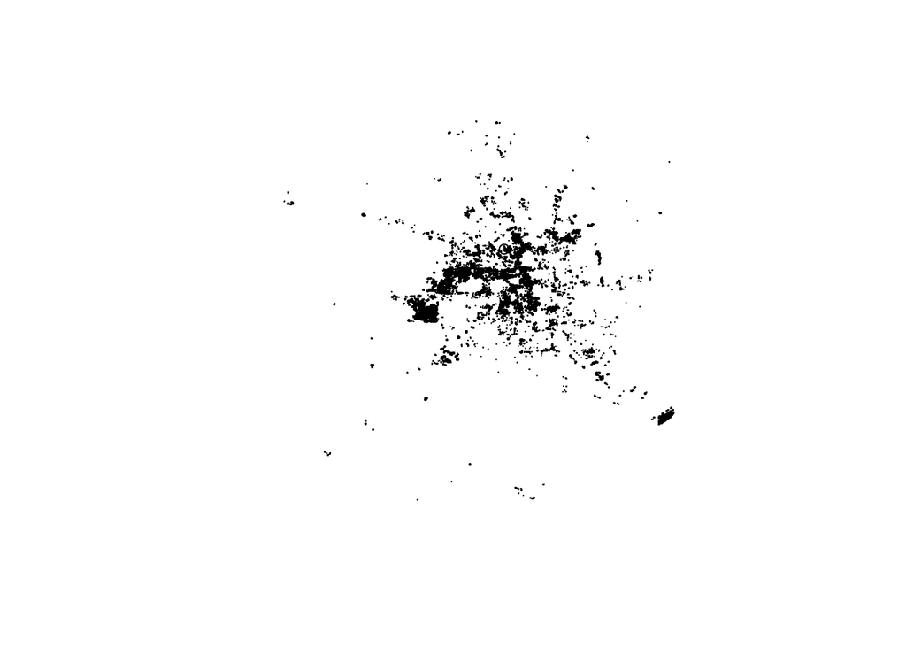

```r
#check the new data by plotting the homes with blackouts
plot(homes_with_blackouts$geom)
```

```r
#Find how many homes were affected
nrow(homes_with_blackouts)
```

```
## [1] 168874
```

There were 168,874 homes affected by the blackouts in Houston.

## Investigate socioeconomic factors

Find which census tracts had blackouts:

```r
#Check the CRS of the census_income data
crs(census_income)
```

```
## [1] "PROJCRS[\"NAD83 / Texas Centric Albers Equal Area\",\n    BASEGEOGCRS[\"NAD83\",\n        DATUM[\"North American Datum 1983\",\n            ELLIPSOID[\"GRS 1980\",6378137,298.257222101,\n                LENGTHUNIT[\"metre\",1]]],\n        PRIMEM[\"Greenwich\",0,\n            ANGLEUNIT[\"degr…
```

```r
#Check the CRS of the houston polygon
crs(Houston)
```

```
## Coordinate Reference System:
## Deprecated Proj.4 representation: +proj=longlat +datum=WGS84 +no_defs
## WKT2 2019 representation:
## GEOGCRS["WGS 84",
##     ENSEMBLE["World Geodetic System 1984 ensemble",
##         MEMBER["World Geodetic System 1984 (Transit)"],
##         MEMBER["World Geodetic System 1984 (G730)"],
##         MEMBER["World Geodetic System 1984 (G873)"],
##         MEMBER["World Geodetic System 1984 (G1150)"],
##         MEMBER["World Geodetic System 1984 (G1674)"],
##         MEMBER["World Geodetic System 1984 (G1762)"],
##         MEMBER["World Geodetic System 1984 (G2139)"],
##         ELLIPSOID["WGS 84",6378137,298.257223563,
##             LENGTHUNIT["metre",1]],
##         ENSEMBLEACCURACY[2.0]],
##     PRIMEM["Greenwich",0,
##         ANGLEUNIT["degree",0.0174532925199433]],
##     CS[ellipsoidal,2],
##         AXIS["geodetic latitude (Lat)",north,
##             ORDER[1],
##             ANGLEUNIT["degree",0.0174532925199433]],
##         AXIS["geodetic longitude (Lon)",east,
##             ORDER[2],
##             ANGLEUNIT["degree",0.0174532925199433]],
##     USAGE[
##         SCOPE["Horizontal component of 3D system."],
##         AREA["World."],
##         BBOX[-90,-180,90,180]],
##     ID["EPSG",4326]]
```

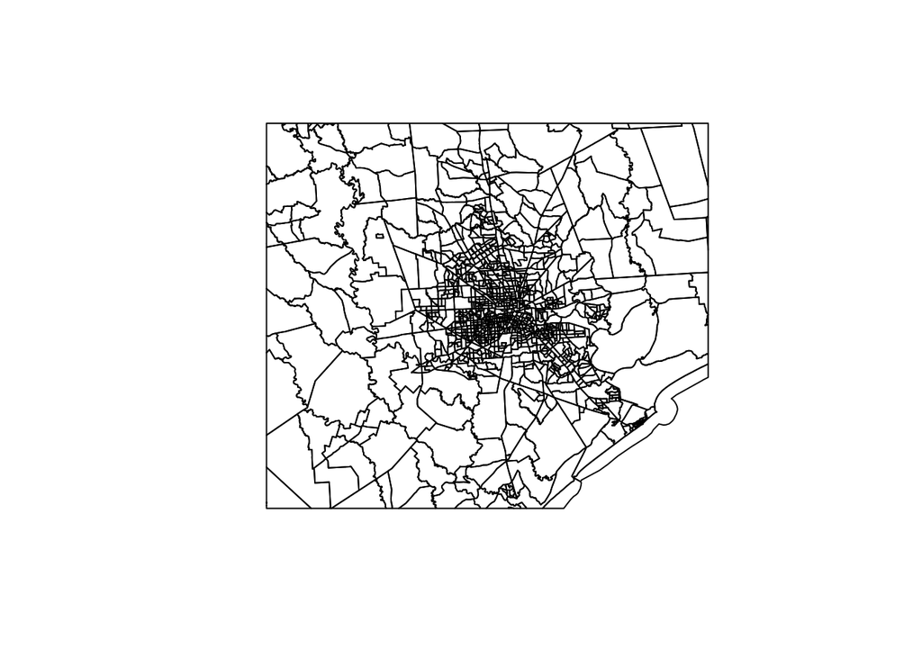

```r
#Transform the Houston Polygon to the same CRS as the census income info
Houston <- Houston %>%
  st_transform('EPSG:3083')

# Use st_crop to crop the Texas Census Data to Houston Boundaries
census_houston <- st_crop(census_income, Houston)

#Plot the data to check it's cropped
plot(census_houston$Shape)
```

```r
#Combine the Census data with the blackout data, set available values equal to ture
combined <- st_join(census_houston, homes_with_blackouts, left = TRUE)
#Set the NA Values equal to False
combined$VNP46A1.A2021038.h08v05.001.2021039064328.tif[is.na(combined$VNP46A1.A2021038.h08v05.001.2021039064328.tif)] <- "FALSE"
```

```r
#Create a new variable to identify just the tracts that experienced blackouts
trac_with_blackout <- combined %>%
  filter(combined$VNP46A1.A2021038.h08v05.001.2021039064328.tif == TRUE)
##Create a new variable to identify just the tracts that didnt experience blackouts
trac_without_blackout <- combined %>%
  filter(combined$VNP46A1.A2021038.h08v05.001.2021039064328.tif == FALSE)
```

- create a map of median income by census tract, designating which tracts had blackouts

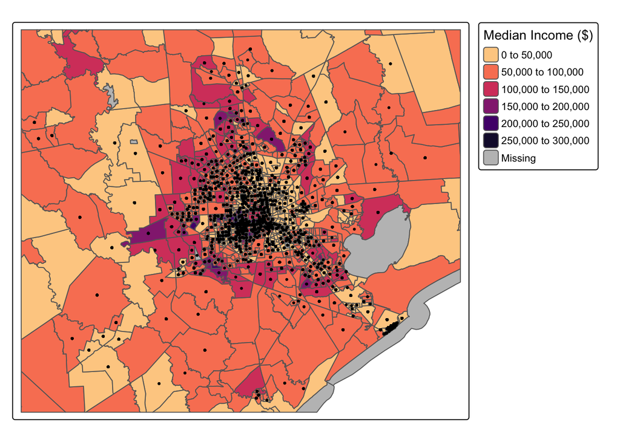

```r
#Create a map of median income by census tract, designating which tracts had blackouts
tm_shape(census_houston) +
  tm_polygons("median_income",
          title = "Median Income ($)",
          palette = "magma") +
  tm_shape(trac_with_blackout) +
  tm_dots()
```

```r
  tm_shape(trac_with_blackout) +
  tm_polygons("median_income",
          title = "Median Income ($)",
          palette = "RdPu")
```

[figure not shown]

```r
  tm_shape(trac_without_blackout) +
  tm_polygons("median_income",
          title = "Median Income ($)",
          palette = "RdPu")
```

[figure not shown]

- plot the distribution of income in impacted and unimpacted tracts

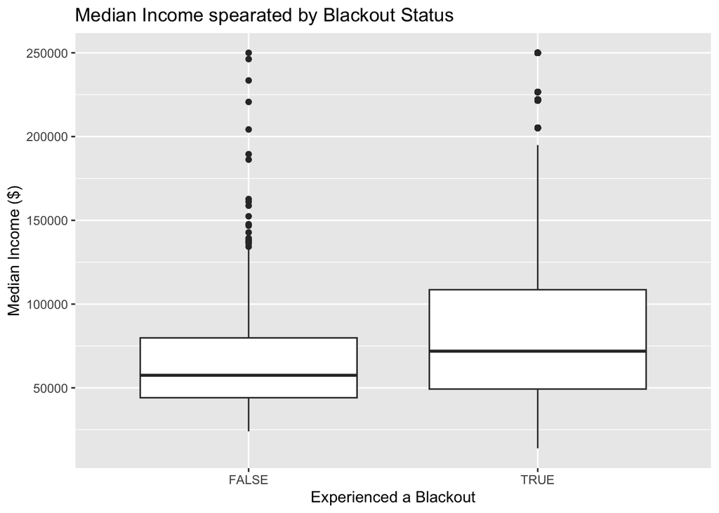

```r
ggplot(combined, aes(x=VNP46A1.A2021038.h08v05.001.2021039064328.tif, y=median_income))+
  geom_boxplot()+
  labs(x = "Experienced a Blackout",
       y = 'Median Income ($)',
       title = "Median Income spearated by Blackout Status")
```

This distribution was originally surprising to me because I expected there to be some information about lower-income census tracts being affected by the blackouts. I noticed from this data that so many buildings were affected by the blackouts; they weren’t based on income. The income from the census tracts that didn’t experience a blackout was lower than the census tracts that did because so few census tracts avoided the blackouts. The main limitation that I could identify in this study is that the original data wasn’t available in the same projection. In order to join the spatial data, we had to reproject the data, which required the use of the st_make_valid() function in a few places in order for the code to run. Ideally, we could find data that was available in the same projection, so the geometries were more consistent.